# OncoSimulR: forward genetic simulation in asexual populations with arbitrary epistatic interactions and a focus on modeling tumor progression.

# 10 Measures of evolutionary predictability and genotype diversity

Several measures of evolutionary predictability have been proposed in the literature (see, e.g., Szendro, Franke, et al. (2013) and references therein). We provide two, Lines of Descent (LOD) and Path of the Maximum (POM), following Szendro, Franke, et al. (2013); we also provide a simple measure of diversity of the actual genotypes sampled.

In Szendro, Franke, et al. (2013) “(…) paths defined as the time ordered sets of genotypes that at some time contain the largest subpopulation” are called “Path of the Maximum” (POM) (see their p. 572). In our case, POM are obtained from the `pops.by.time` returned object (i.e., from the genotypes at each of the sampling times) and, thus, the POMs will be affected by how often we sample and keep samples (arguments `sampleEvery` and `keepEvery`), since we are running a continuous time process.

Szendro, Franke, et al. (2013) also define Lines of Descent (LODs) which “(…) represent the lineages that arrive at the most populated genotype at the final time”. In that same page (572) they provide the details on how the LODs are obtained. My implementation is not exactly identical to the definition given in p. 572 of Szendro et al. First, in case this might be useful, for each simulation I keep all the paths that “(…) arrive at the most populated genotype at the final time” (first paragraph in p. 572 of Szendro et al.), whereas they only keep one (see second column of p. 572). However, I do provide a single LOD for each run, too. This is the first path to arrive at the genotype that eventually becomes the most populated genotype at the final time (and, in this sense, agrees with the LOD of Szendro et al.). However, in contrast to what is apparently done in Szendro (“A given genotype may undergo several episodes of colonization and extinction that are stored by the algorithm, and the last episode before the colonization of the final state is used to construct the step.”), I do not check that this genotype (which is the one that will become the most populated at final time) does not become extinct before the final colonization. So there could be other paths (all in `all_paths`) that are actually the one(s) that are colonizers of the most populated genotype (with no extinction before the final colonization). Obtaining LOD requires that the simulations be run with `keepPhylog = TRUE` (we need the genealogy of clones).

To briefly show some output, we will use again the 5.5 example. Note that using LOD requires running the simulations with `keepPhylog = TRUE`.

```r
pancr <- allFitnessEffects(
    data.frame(parent = c("Root", rep("KRAS", 4), "SMAD4", "CDNK2A",
                          "TP53", "TP53", "MLL3"),
               child = c("KRAS","SMAD4", "CDNK2A",
                         "TP53", "MLL3",
                         rep("PXDN", 3), rep("TGFBR2", 2)),
               s = 0.05, sh = -0.3, typeDep = "MN"))

pancr16 <- oncoSimulPop(16, pancr, model = "Exp", keepPhylog = TRUE,
                        mc.cores = 2)

## Look a the first POM
str(POM(pancr16)[1:3])
```

```
## List of 3
##  $ : chr [1:3] "" "KRAS" "CDNK2A, KRAS"
##  $ : chr [1:2] "" "KRAS"
##  $ : chr [1:2] "" "KRAS"
```

```r
## Note here that for each simulation there is a "all_paths" and
## a "lod_single", as explained above
LOD(pancr16)[1:2]
## [[1]]
## [[1]]$all_paths
## [[1]]$all_paths[[1]]
## + 3/? vertices, named:
## [1]              KRAS         CDNK2A, KRAS
##
##
## [[1]]$lod_single
## + 3/? vertices, named:
## [1]              KRAS         CDNK2A, KRAS
##
##
## [[2]]
## [[2]]$all_paths
## [[2]]$all_paths[[1]]
## + 2/? vertices, named:
## [1]      KRAS
##
##
## [[2]]$lod_single
## + 2/? vertices, named:
## [1]      KRAS

## The diversity of LOD (lod_single) and POM might or might not
## be identical
diversityPOM(POM(pancr16))
```

```
## [1] 0.4634
```

```r
diversityLOD(LOD(pancr16))
```

```
## [1] 0.4634
```

```r
## Show the genotypes and their diversity (which might, or might
## not, differ from the diversity of LOD and POM)
sampledGenotypes(samplePop(pancr16))
```

```
##
##  Subjects by Genes matrix of 16 subjects and 7 genes.
##       Genotype Freq
## 1 CDNK2A, KRAS    1
## 2         KRAS   14
## 3  KRAS, SMAD4    1
##
##  Shannon's diversity (entropy) of sampled genotypes: 0.4634
```

# 11 Generating random DAGs for restrictions

You might want to randomly generate DAGs like those often found in the literature on Oncogenetic trees et al. Function `simOGraph` might help here.

```r
## No seed fixed, so reruns will give different DAGs.
(a1 <- simOGraph(10))
```

```
##      Root 1 2 3 4 5 6 7 8 9 10
## Root    0 1 1 1 1 0 0 0 0 0  0
## 1       0 0 0 0 0 1 0 0 0 0  0
## 2       0 0 0 0 0 1 0 0 0 0  0
## 3       0 0 0 0 0 0 1 0 0 0  0
## 4       0 0 0 0 0 1 0 0 0 0  0
## 5       0 0 0 0 0 0 1 0 0 0  0
## 6       0 0 0 0 0 0 0 1 1 1  1
## 7       0 0 0 0 0 0 0 0 0 0  0
## 8       0 0 0 0 0 0 0 0 0 0  0
## 9       0 0 0 0 0 0 0 0 0 0  0
## 10      0 0 0 0 0 0 0 0 0 0  0
```

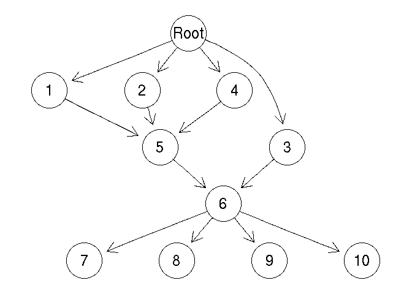

```r
library(graph) ## for simple plotting
plot(as(a1, "graphNEL"))
```

Once you obtain the adjacency matrices, it is for now up to you to convert them into appropriate posets or fitnessEffects objects.

Why this function? I searched for, and could not find any that did what I wanted, in particular bounding the number of parents, being able to specify the approximate depth[^14] of the graph, and optionally being able to have DAGs where no node is connected to another both directly (an edge between the two) and indirectly (there is a path between the two through other nodes). So I wrote my own code. The code is fairly simple to understand (all in file `generate-random-trees.R`). I would not be surprised if this way of generating random graphs has been proposed and named before; please let me know, best if with a reference.

Should we remove direct connections if there are indirect? Or, should we set `removeDirectIndirect = TRUE`? Except for Farahani and Lagergren (2013) and Ramazzotti et al. (2015), none of the DAGs I’ve seen in the context of CBNs, Oncogenetic trees, etc, include both direct and indirect connections between nodes. If these exist, reasoning about the model can be harder. For example, with CBN (AND or CMPN or monotone relationships) adding a direct connection makes no difference iff we assume that the relationships encoded in the DAG are fully respected (e.g., all $s_h = -\infty$). But it can make a difference if we allow for deviations from the monotonicity, specially if we only check for the satisfaction of the presence of the immediate ancestors. And things get even trickier if we combine XOR with AND. The code for computing fitness, however, should deal with all of this just fine.

# 12 FAQ, odds and ends

## 12.1 What we mean by “clone”; and “I want clones disregarding passengers”

In this vignette we often use “clone” or “genotype” interchangeably. A clone denotes a set of cells that have identical genotypes. So if you are using a fitness specification with four genes (i.e., your genome has only four loci), there can be up to $16 = 2^4$ different genotypes or clones. Any two entities that differ in the genotype are different clones. And this applies regardless of whether or not you declare that some genes (loci) are drivers or not. So if you have four genes, it does not matter whether only the first or all four are regarded as drivers; you will always have at most 16 different clones or 16 different genotypes. Of course you can arrive at the same clone/genotype by different routes. Just think about loci A and B in our four-loci genome, and how you can end up with a cell with both A and B mutated.

Analogously, if you have 100 genes, 10 drivers and 90 passengers, you can have up to $2^{100}$ different clones or genotypes. Sure, one cell might have driver A mutated and passenger B mutated, and another cell might have driver A mutated and passenger C mutated. So if you only look at drivers you might be tempted to say that they are “the same clone for all practical purposes”; but they really are not the same clone as they differ in their genotype and this makes a lot of difference computationally.

If you want summaries of simulations that collapse over some genes (say, some “passengers”, the 90 passengers we just mentioned) look at the help for `samplePop`, argument `geneNames`. This would allow you, for instance, to look at the diversity of clones/genotypes, considering as identical those genotypes that only differ in genes you deem relevant; something similar to defining a “drivers’ clone” as the set formed from the union of all sets of cells that have identical genotype with respect to only the drivers (so that in the example of “A, B” and “A, C” just mentioned both cells would be considered “the same clone” as they only differ with respect to passengers). However, this “disregard some genes” only applies to summaries of simulations once we are done simulating data. OncoSimulR will always track clones, as defined above, regardless of whether many of those clones have the same genotype if you were to only focus on driver genes; see also section 12.2.

Labeling something as a “driver”, therefore, does not affect what we mean by clone. Yes, labeling something as a driver can affect when you stop simulations if you use `detectionDrivers` as a stopping mechanism (see section 6.3). But, again, this has nothing to do with the definition of “clone”.

If this is all obvious to you, ignore it. I am adding it here because I’ve seen strange misunderstandings that eventually could be traced to the apparently multiple meanings of clone. (And to make the story complete, Mather, Hasty, and Tsimring (2012) use the expression “class” —e.g., Algorithm 4 in the paper, Algorithm 5 in the supplementary material).

## 12.2 Does OncoSimulR keep track of individuals or of clones? And how can it keep track of such large populations?

OncoSimulR keeps track of clones, where a clone is a set of cells that are genetically identical (note that this means completely identical over the whole set of genes/markers you are using; see section 12.1). We do not need to keep track of individual cells because, for all purposes, and since we do not consider spatial structure, two or more cells that are genetically identical are interchangeable. This means, for instance, that the computational cost of keeping a population of a single clone with 1 individual or with $10^9$ individuals is exactly the same: we just keep track of the genotype and the number of cells. (Sure, it is much more likely we will see a mutation soon in a clone with $10^9$ cells than in a clone with 1, but that is a different issue.)

Of course, the entities that die, reproduce, and mutate are individual cells. This is of course dealt with by tracking clones (as is clearly shown by Algorithms 4 and 5 in Mather, Hasty, and Tsimring (2012)). Tracking individuals, as individuals, would provide no advantage, but would increase the computational burden by many orders of magnitude.

### 12.2.1 `sampleEvery`, `keepPhylog`, and pruning

At each sampling time (where `sampleEvery` determines the time units between sampling times) the abundance of all the clones with number of cells $>0$ is recorded. This is the structure that at the end of the run is converted into the `pops.by.time` matrix.

Now, some clones might arise from mutation between successive population samples but these clones might be extinct by the time we take a population sample. These clones do not appear in the `pops.by.time` matrix because, as we just said, they have 0 cells at the time of sampling. Of course, some of these clones might appear again later and reach a size larger than 0 at some posterior sampling time; it is at this time when this/these clone(s) will appear in the `pops.by.time` matrix. This pruning of clones with 0 cells can allow considerable savings in computing time (OncoSimulR needs to track the genotype of clones, their population sizes, their birth, death, and mutation rates, their next mutation time and the last time they were updated and thus it is important that we only loop over structures with information that is really needed).

However, we still need to track clones as clones, not simply as classes such as “number of mutated genes”. Therefore, very large genomes can represent a problem if they lead to the creation and tracking of many different clones (even if they have the same number of mutated genes), as we have seen, for instance, in section 2.3. In this case, programs that only keep track of numbers of mutated genes or of drivers, not individual clones, can of course achieve better speed.

What about the genealogy? If you ask OncoSimulR to keep track of the complete parent-child relationships (`keepPhylog = TRUE`), you might see in the genealogy clones that are not present in `pops.by.time` if these are clones that never had a population size larger than 0 at any sampling time. To give an example, suppose that we will take population samples at times 0, 1, and 2. Clone A, with a population size larger than 0 at time 1, gives rise at time 1.5 to clone B; clone B then gives rise to clone C at time 1.8. Finally, suppose that at time 2 only clone C is alive. In other words, when we carry out the update of the population with Algorithm 5 from Mather, Hasty, and Tsimring (2012), clones A and B have size 0. Now, at time 1 clones B and C did not yet exist, and clone B is never alive at times 1 or 2. Thus, clone B is not present in `pops.by.time`. But we cannot remove clone B from our genealogy if we want to reflect the complete genealogy of C. Thus, `pops.by.time` will show only clones A and C (not B) but the complete genealogy will show clones A, B, C (and will show that B appeared from A at time 1.5 and C appeared from B at time 1.8). Since function `plotClonePhylog` offers a lot of flexibility with respect to what clones to show depending on their population sizes at different times, you can prevent being shown B, but its existence is there should you need it (see also 2.3.5).

## 12.3 Dealing with errors in “oncoSimulPop”

When running OncoSimulR under Windows `mclapply` does not use multiple cores, and errors from `oncoSimulPop` are reported directly. For example:

```r
## This code will only be evaluated under Windows
if(.Platform$OS.type == "windows")
    try(pancrError <- oncoSimulPop(10, pancr,
                               initSize = 1e-5,
                               detectionSize = 1e7,
                               keepEvery = 10,
                               mc.cores = 2))
```

Under POSIX operating systems (e.g., GNU/Linux or Mac OSX) `oncoSimulPop` can ran parallelized by calling `mclapply`. Now, suppose you did something like

```r
## Do not run under Windows
if(.Platform$OS.type != "windows")
    pancrError <- oncoSimulPop(10, pancr,
                               initSize = 1e-5,
                               detectionSize = 1e7,
                               keepEvery = 10,
                               mc.cores = 2)
```

```
## Warning in mclapply(seq.int(Nindiv), function(x) oncoSimulIndiv(fp =
## fp, : all scheduled cores encountered errors in user code
```

The warning you are seeing tells you there was an error in the functions called by `mclapply`. If you check the help for `mclpapply` you’ll see that it returns a try-error object, so we can inspect it. For instance, we could do:

```r
pancrError[[1]]
```

But the output of this call might be easier to read:

```r
pancrError[[1]][1]
```

And from here you could see the error that was returned by `oncoSimulIndiv`: `initSize < 1` (which is indeed true: we pass `initSize = 1e-5`).

## 12.4 Whole tumor sampling, genotypes, and allele counts: what gives? And what about order?

You are obtaining genotypes, regardless of order. When we use “whole tumor sampling”, it is the frequency of the mutations in each gene that counts, not the order. So, for instance, “c, d” and “c, d” both contribute to the counts of “c” and “d”. Similarly, when we use single cell sampling, we obtain a genotype defined in terms of mutations, but there might be multiple orders that give this genotype. For example, $d > c$ and $c > d$ both give you a genotype with “c” and “d” mutated, and thus in the output you can have two columns with both genes mutated.

## 12.5 Doesn’t the BNB algorithm require small mutation rates for it to be advantageous?

As discussed in the original paper by Mather, Hasty, and Tsimring (2012) (see also their supplementary material), the BNB algorithm can achieve considerable speed advantages relative to other algorithms especially when mutation events are rare relative to birth and death events; the larger the mutation rate, the smaller the gains compared to other algorithms. As mentioned in their supplementary material (see p.5) “Note that the ‘cost’ of each step in BNB is somewhat higher than in SSA [SSA is the original Gillespie’s Stochastic Simulation Algorithm] since it requires generation of several random numbers as compared to only two uniform random numbers for SSA. However this cost increase is small compared with significant benefits of jumping over birth and death reactions for the case of rare mutations.”

Since the earliest versions, OncoSimulR has provided information to assess these issues. The output of function `oncoSimulIndiv` includes a list called *“other”* that itself includes two lists named *“minDMratio”* and *“minBMratio”*, the smallest ratio, over all simulations, of death rate to mutation rate or birth rate to mutation rate, respectively. As explained above, the BNB algorithm thrives when those are large. Note, though, we say “it thrives”: these ratios being large is not required for the BNB algorithm to be an exact simulation algorithm; these ratios being large make BNB comparatively much faster than other algorithms.

## 12.6 Can we use the BNB algorithm with state-dependent birth or death rates?

As discussed in the original paper by Mather, Hasty, and Tsimring (2012) (see sections 2.6 and 3.2 of the paper and section E of the supplementary material), the BNB algorithm can be used as an approximate stochastic simulation algorithm “(…) with non-constant birth, death, and mutation rates by evolving the system with a BNB step restricted to a short duration t.” (p. 9 in supplementary material). The justification is that “(…) the propensities for reactions can be considered approximately constant during some short interval.” (p. 1234). This is the reason why, when we use McFarland’s model, we set a very short `sampleEvery`. In addition, the output of the simulation functions contains the simple summary statistic `errorMF` that can be used to assess the quality of the approximation[^15].

Note that, as the authors point out, approximations are common with stochastic simulation algorithms when there is density dependence, but the advantage of the BNB algorithm compared to, say, most tau-leap methods is that clones of different population sizes are treated uniformly. Mather, Hasty, and Tsimring (2012) further present results from simulations comparing the BNB algorithm with the original direct SSA method and the tau-leaps (see their Fig. 5), which shows that the approximation is very accurate as soon as the interval between samples becomes reasonably short.

## 12.7 Sometimes I get exceptions when running with mutator genes

Yes, sure, the following will cause an exception; this is similar to the example used in 1.3.4 but there is one crucial difference:

```r
sd <- 0.1 ## fitness effect of drivers
sm <- 0 ## fitness effect of mutator
nd <- 20 ## number of drivers
nm <- 5  ## number of mutators
mut <- 50 ## mutator effect  THIS IS THE DIFFERENCE

fitnessGenesVector <- c(rep(sd, nd), rep(sm, nm))
names(fitnessGenesVector) <- 1:(nd + nm)
mutatorGenesVector <- rep(mut, nm)
names(mutatorGenesVector) <- (nd + 1):(nd + nm)

ft <- allFitnessEffects(noIntGenes = fitnessGenesVector,
                        drvNames = 1:nd)
mt <- allMutatorEffects(noIntGenes = mutatorGenesVector)
```

Now, simulate using the fitness and mutator specification. We fix the number of drivers to cancer, and we stop when those numbers of drivers are reached. Since we only care about the time it takes to reach cancer, not the actual trajectories, we set `keepEvery = NA`:

```r
ddr <- 4
set.seed(2)
RNGkind("L'Ecuyer-CMRG")
st <- oncoSimulPop(4, ft, muEF = mt,
                   detectionDrivers = ddr,
                   finalTime = NA,
                   detectionSize = NA,
                   detectionProb = NA,
                   onlyCancer = TRUE,
                   keepEvery = NA,
                   mc.cores = 2, ## adapt to your hardware
                   seed = NULL) ## for reproducibility
set.seed(NULL) ## return things to their "usual state"
```

What happened? That you are using five mutator genes, each with an effect of multiplying by 50 the mutation rate. So the genotype with all those five genes mutated will have an increased mutation rate of $50^5 = 312500000$. If you set the mutation rate to the default of $1e-6$ you have a mutation rate of 312 which makes no sense (and leads to all sorts of numerical issues down the road and an early warning).

Oh, but you want to accumulate mutator effects and have some, or the early ones, have a large effects and the rest progressively smaller effects? You can do that using epistatic effects for mutator effects.

## 12.8 What are good values of `sampleEvery`?

First, we need to differentiate between the McFarland and the exponential models. If you use the McFarland model, you should read section 12.6 but, briefly, the small default is probably a good choice.

With the exponential model, however, simulations can often be much faster if `sampleEvery` is large. How large? As large as you can make it. `sampleEvery` should not be larger than your desired `keepEvery`, where `keepEvery` determines the resolution or granularity of your samples (i.e., how often you take a snapshot of the population). If you only care about the final state, then set `keepEvery = NA`.

The other factors that affects choosing a reasonable `sampleEvery` are mutation rate and population size. If population growth is very fast or mutation rate very large, you need to sample frequently to avoid the “Recoverable exception ti set to DBL_MIN. Rerunning.” issue (see discussion in section 2.4).

## 12.9 What can you do with the simulations?

This is up to you. In section 13.2 we show an example where we infer an Oncogenetic tree from simulated data and in section 1.3 we go over a varied set of scientific questions where OncoSimulR could help.

# 13 Using v.1 posets and simulations

It is strongly recommended that you use the new (v.2) procedures for specifying fitness effects. However, the former v.1 procedures are still available, with only very minor changes to function calls. What follows below is the former vignette. You might want to use v.1 because for certain models (e.g., small number of genes, with restrictions as specified by a simple poset) simulations might be faster with v.1 (fitness evaluation is much simpler —we are working on further improving speed).

## 13.1 Specifying restrictions: posets

How to specify the restrictions is shown in the help for `poset`. It is often useful, to make sure you did not make any mistakes, to plot the poset. This is from the examples (we use an “L” after a number so that the numbers are integers, not doubles; we could alternatively have modified `storage.mode`).

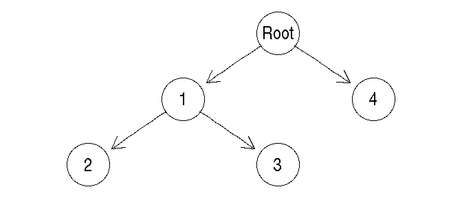

```r
## Node 2 and 3 depend on 1, and 4 depends on no one
p1 <- cbind(c(1L, 1L, 0L), c(2L, 3L, 4L))
plotPoset(p1, addroot = TRUE)
```

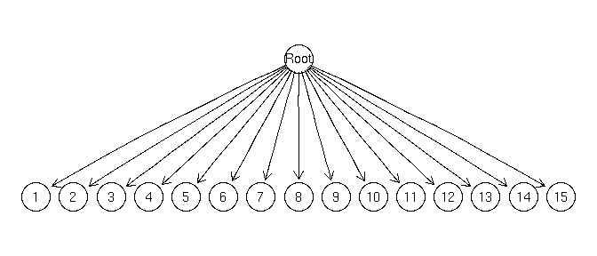

```r
## A simple way to create a poset where no gene (in a set of 15)
## depends on any other.
p4 <- cbind(0L, 15L)
plotPoset(p4, addroot = TRUE)
```

Specifying posets is actually straightforward. For instance, we can specify the pancreatic cancer poset in Gerstung et al. (2011) (their figure 2B, left). We specify the poset using numbers, but for nicer plotting we will use names (KRAS is 1, SMAD4 is 2, etc). This example is also in the help for `poset`:

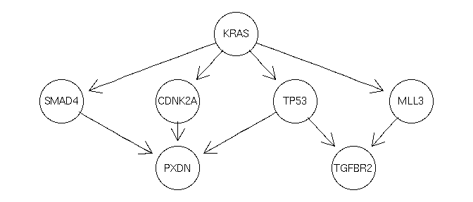

```r
pancreaticCancerPoset <- cbind(c(1, 1, 1, 1, 2, 3, 4, 4, 5),
                               c(2, 3, 4, 5, 6, 6, 6, 7, 7))
storage.mode(pancreaticCancerPoset) <- "integer"
plotPoset(pancreaticCancerPoset,
          names = c("KRAS", "SMAD4", "CDNK2A", "TP53",
                    "MLL3","PXDN", "TGFBR2"))
```

## Simulating cancer progression {#simul1}

We can simulate the progression in a single subject. Using an example very similar to the one in the help:

```r
## use poset p1101
data(examplePosets)
p1101 <- examplePosets[["p1101"]]

## Bozic Model
b1 <- oncoSimulIndiv(p1101, keepEvery = 15)
summary(b1)
```

```
##   NumClones TotalPopSize LargestClone MaxNumDrivers
## 1        14     23624449     12058433             4
##   MaxDriversLast NumDriversLargestPop TotalPresentDrivers
## 1              4                    2                   7
##   FinalTime NumIter HittedWallTime HittedMaxTries errorMF
## 1      1554    3020          FALSE          FALSE      NA
##   minDMratio minBMratio     OccurringDrivers
## 1      90909      90909 1, 2, 3, 7, 8, 9, 10
```

If you want to plot the trajectories, it is better to keep more frequent samples, so you can see when clones appear:

```r
b2 <- oncoSimulIndiv(p1101, keepEvery = 1)
summary(b2)
```

```
##   NumClones TotalPopSize LargestClone MaxNumDrivers
## 1        12      5722238      3692638             4
##   MaxDriversLast NumDriversLargestPop TotalPresentDrivers
## 1              4                    2                   7
##   FinalTime NumIter HittedWallTime HittedMaxTries errorMF
## 1      1618    2027          FALSE          FALSE      NA
##   minDMratio minBMratio    OccurringDrivers
## 1      90909      90909 1, 2, 3, 4, 5, 6, 7
```

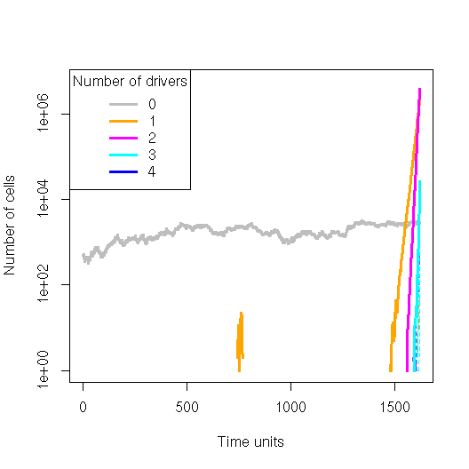

```r
plot(b2)
```

As we have seen before, the stacked plot here is less useful and that is why I do not evaluate that code for this vignette.

```r
plot(b2, type = "stacked")
```

The following is an example where we do not care about passengers, but we want to use a different graph, and we want a few more drivers before considering cancer has been reached. And we allow it to run for longer. Note that in the McFL model `detectionSize` really plays no role. Note also how we pass the poset: it is the same as before, but now we directly access the poset in the list of posets.

```r
m2 <- oncoSimulIndiv(examplePosets[["p1101"]], model = "McFL",
                     numPassengers = 0, detectionDrivers = 8,
                     mu = 5e-7, initSize = 4000,
                     sampleEvery = 0.025,
                     finalTime = 25000, keepEvery = 5,
                     detectionSize = 1e6)
```

(Very rarely the above run will fail to reach cancer. If that happens, execute it again.)

As usual, we will plot using both a line and a stacked plot:

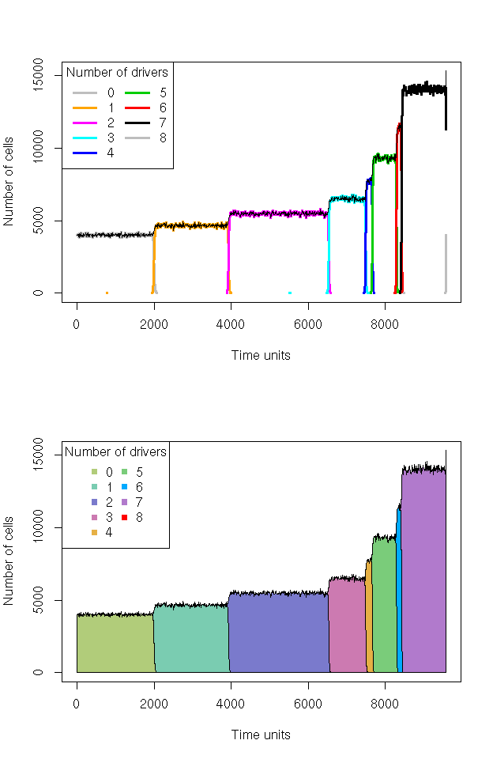

```r
par(mfrow = c(2, 1))
plot(m2, addtot = TRUE, log = "",
     thinData = TRUE, thinData.keep = 0.5)
plot(m2, type = "stacked",
     thinData = TRUE, thinData.keep = 0.5)
```

The default is to simulate progression until a simulation reaches cancer (i.e., only simulations that satisfy the detectionDrivers or the detectionSize will be returned). If you use the McFL model with large enough `initSize` this will often be the case but not if you use very small `initSize`. Likewise, most of the Bozic runs do not reach cancer. Lets try a few:

```r
b3 <- oncoSimulIndiv(p1101, onlyCancer = FALSE)
summary(b3)
```

```
##   NumClones TotalPopSize LargestClone MaxNumDrivers
## 1         1            0            0             0
##   MaxDriversLast NumDriversLargestPop TotalPresentDrivers
## 1              0                    0                   0
##   FinalTime NumIter HittedWallTime HittedMaxTries errorMF
## 1       751     753          FALSE          FALSE      NA
##   minDMratio minBMratio OccurringDrivers
## 1      90909      90909               NA
```

```r
b4 <- oncoSimulIndiv(p1101, onlyCancer = FALSE)
summary(b4)
```

```
##   NumClones TotalPopSize LargestClone MaxNumDrivers
## 1         1            0            0             0
##   MaxDriversLast NumDriversLargestPop TotalPresentDrivers
## 1              0                    0                   0
##   FinalTime NumIter HittedWallTime HittedMaxTries errorMF
## 1       104     104          FALSE          FALSE      NA
##   minDMratio minBMratio OccurringDrivers
## 1      90909      90909               NA
```

Plot those runs:

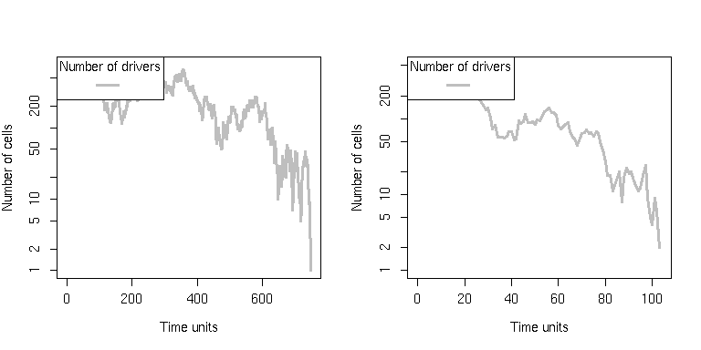

```r
par(mfrow = c(1, 2))
par(cex = 0.8) ## smaller font
plot(b3)
plot(b4)
```

### 13.1.1 Simulating progression in several subjects

To simulate the progression in a bunch of subjects (we will use only four, so as not to fill the vignette with plots) we can do, with the same settings as above:

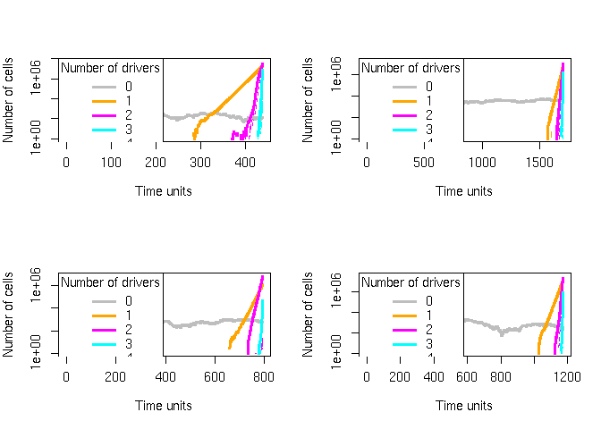

```r
p1 <- oncoSimulPop(4, p1101, mc.cores = 2)
par(mfrow = c(2, 2))
plot(p1, ask = FALSE)
```

We can also use stream and stacked plots, though they might not be as useful in this case. For the sake of keeping the vignette small, these are commented out.

```r
par(mfrow = c(2, 2))
plot(p1, type = "stream", ask = FALSE)
```

```r
par(mfrow = c(2, 2))
plot(p1, type = "stacked", ask = FALSE)
```

## 13.2 Sampling from a set of simulated subjects

You will often want to do something with the simulated data. For instance, sample the simulated data. Here we will obtain the trajectories for 100 subjects in a scenario without passengers. Then we will sample with the default options and store that as a vector of genotypes (or a matrix of subjects by genes):

```r
m1 <- oncoSimulPop(100, examplePosets[["p1101"]],
                   numPassengers = 0, mc.cores = 2)
```

The function `samplePop` samples that object, and also gives you some information about the output:

```r
genotypes <- samplePop(m1)
```

```
##
##  Subjects by Genes matrix of 100 subjects and 11 genes.
```

What can you do with it? That is up to you. As an example, let us try to infer an Oncogenetic tree (and plot it) using the *[Oncotree](http://cran.fhcrc.org/web/packages/Oncotree/index.html)* package Szabo and Pappas (2013) after getting a quick look at the marginal frequencies of events:

```r
colSums(genotypes)/nrow(genotypes)
```

```
##    1    2    3    4    5    6    7    8    9   10   11
## 0.49 0.04 0.02 0.00 0.00 0.00 0.54 0.03 0.04 0.00 0.00
```

```r
require(Oncotree)
```

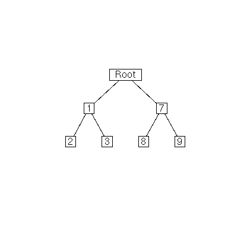

```r
ot1 <- oncotree.fit(genotypes)
## The following events had no observed occurances,so they will not be included in the construction of the tree:
## 4 5 6 10 11
plot(ot1)
```

Your run will likely differ from mine, but with the defaults (detection size of $10^8$) it is likely that events down the tree will never appear. You can set `detectionSize = 1e9` and you will see that events down the tree are now found in the cross-sectional sample.

Alternatively, you can use single cell sampling and that, sometimes, recovers one or a couple more events.

```r
genotypesSC <- samplePop(m1, typeSample = "single")
```

```
##
##  Subjects by Genes matrix of 100 subjects and 11 genes.
```

```r
colSums(genotypesSC)/nrow(genotypesSC)
```

```
##    1    2    3    4    5    6    7    8    9   10   11
## 0.59 0.06 0.12 0.00 0.00 0.00 0.65 0.08 0.14 0.00 0.00
```

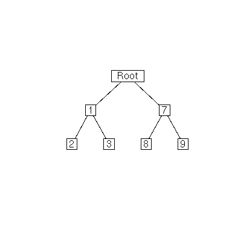

```r
ot2 <- oncotree.fit(genotypesSC)
## The following events had no observed occurances,so they will not be included in the construction of the tree:
## 4 5 6 10 11
plot(ot2)
```

You can of course rename the columns of the output matrix to something else if you want so the names of the nodes will reflect those potentially more meaningful names.

# 14 Session info and packages used

This is the information about the version of R and packages used:

```r
sessionInfo()
## R Under development (unstable) (2016-11-03 r71622)
## Platform: x86_64-pc-linux-gnu (64-bit)
## Running under: Debian GNU/Linux stretch/sid
##
## locale:
##  [1] LC_CTYPE=en_GB.utf8       LC_NUMERIC=C
##  [3] LC_TIME=en_GB.utf8        LC_COLLATE=en_GB.utf8
##  [5] LC_MONETARY=en_GB.utf8    LC_MESSAGES=en_GB.utf8
##  [7] LC_PAPER=en_GB.utf8       LC_NAME=C
##  [9] LC_ADDRESS=C              LC_TELEPHONE=C
## [11] LC_MEASUREMENT=en_GB.utf8 LC_IDENTIFICATION=C
##
## attached base packages:
## [1] parallel  methods   stats     graphics  grDevices
## [6] utils     datasets  base
##
## other attached packages:
##  [1] Oncotree_0.3.3      boot_1.3-18
##  [3] igraph_1.0.1        graph_1.53.0
##  [5] BiocGenerics_0.21.0 pander_0.6.0
##  [7] BiocStyle_2.3.3     rmarkdown_1.1
##  [9] testthat_1.0.2      OncoSimulR_2.5.8
##
## loaded via a namespace (and not attached):
##  [1] gtools_3.5.0       splines_3.4.0
##  [3] lattice_0.20-34    colorspace_1.2-7
##  [5] miniUI_0.1.1       htmltools_0.3.5
##  [7] stats4_3.4.0       yaml_2.1.13
##  [9] mgcv_1.8-15        chron_2.3-47
## [11] nloptr_1.0.4       DBI_0.5-1
## [13] Rgraphviz_2.19.0   RColorBrewer_1.1-2
## [15] plyr_1.8.4         stringr_1.1.0
## [17] MatrixModels_0.4-1 munsell_0.4.3
## [19] gtable_0.2.0       evaluate_0.10
## [21] knitr_1.14         SparseM_1.72
## [23] httpuv_1.3.3       quantreg_5.29
## [25] pbkrtest_0.4-6     Rcpp_0.12.7
## [27] xtable_1.8-2       scales_0.4.0
## [29] formatR_1.4        mime_0.5
## [31] lme4_1.1-12        smatr_3.4-3
## [33] ggplot2_2.1.0      digest_0.6.10
## [35] stringi_1.1.2      bookdown_0.1
## [37] dplyr_0.5.0        ggrepel_0.6.3
## [39] shiny_0.14.2       grid_3.4.0
## [41] tools_3.4.0        magrittr_1.5
## [43] lazyeval_0.2.0     tibble_1.2
## [45] crayon_1.3.2       car_2.1-3
## [47] MASS_7.3-45        Matrix_1.2-7.1
## [49] data.table_1.9.6   assertthat_0.1
## [51] minqa_1.2.4        R6_2.2.0
## [53] nnet_7.3-12        nlme_3.1-128
```

# 15 Funding

Supported by BFU2015-67302-R (MINECO/FEDER, EU).

# 16 References

Ashworth, Alan, Christopher J Lord, and Jorge S Reis-Filho. 2011. “Genetic interactions in cancer progression and treatment.” *Cell* 145 (1). Elsevier Inc.: 30–38. doi:10.1016/j.cell.2011.03.020.

Bauer, Benedikt, Reiner Siebert, and Arne Traulsen. 2014. “Cancer initiation with epistatic interactions between driver and passenger mutations.” *Journal of Theoretical Biology* 358. Elsevier: 52–60. doi:10.1016/j.jtbi.2014.05.018.

Beerenwinkel, Niko, Tibor Antal, David Dingli, Arne Traulsen, Kenneth W Kinzler, Victor E Velculescu, Bert Vogelstein, and Martin A Nowak. 2007. “Genetic progression and the waiting time to cancer.” *PLoS Computational Biology* 3 (11): e225. doi:10.1371/journal.pcbi.0030225.

Beerenwinkel, Niko, Nicholas Eriksson, and Bernd Sturmfels. 2007. “Conjunctive Bayesian networks.” *Bernoulli* 13 (4): 893–909. doi:10.3150/07-BEJ6133.

Bozic, Ivana, Tibor Antal, Hisashi Ohtsuki, Hannah Carter, Dewey Kim, Sining Chen, Rachel Karchin, Kenneth W Kinzler, Bert Vogelstein, and Martin A Nowak. 2010. “Accumulation of driver and passenger mutations during tumor progression.” *Proceedings of the National Academy of Sciences of the United States of America* 107 (September): 18545–50. doi:10.1073/pnas.1010978107.

Brouillet, Sophie, Harry Annoni, Luca Ferretti, and Guillaume Achaz. 2015. “MAGELLAN: A Tool to Explore Small Fitness Landscapes.” *BioRxiv*, November, 031583. doi:10.1101/031583.

Carvajal-Rodriguez, Antonio. 2010. “Simulation of Genes and Genomes Forward in Time.” *Current Genomics* 11 (1): 58–61. doi:10.2174/138920210790218007.

Datta, Ruchira S, Alice Gutteridge, Charles Swanton, Carlo C Maley, and Trevor A Graham. 2013. “Modelling the evolution of genetic instability during tumour progression.” *Evolutionary Applications* 6 (1): 20–33. doi:10.1111/eva.12024.

Desper, R, F Jiang, O P Kallioniemi, H Moch, C H Papadimitriou, and A A Schäffer. 1999. “Inferring tree models for oncogenesis from comparative genome hybridization data.” *J Comput Biol* 6 (1): 37–51. http://view.ncbi.nlm.nih.gov/pubmed/10223663.

Diaz-Uriarte, R. 2015. “Identifying restrictions in the order of accumulation of mutations during tumor progression: effects of passengers, evolutionary models, and sampling.” *BMC Bioinformatics* 16 (41): 0–36. doi:doi:10.1186/s12859-015-0466-7.

Farahani, H, and J Lagergren. 2013. “Learning oncogenetic networks by reducing to mixed integer linear programming.” *PloS One* 8 (6): e65773. doi:10.1371/journal.pone.0065773.

Franke, Jasper, Alexander Klözer, J. Arjan G. M. de Visser, and Joachim Krug. 2011. “Evolutionary Accessibility of Mutational Pathways.” *PLoS Comput Biol* 7 (8): e1002134. doi:10.1371/journal.pcbi.1002134.

Gerrish, Philip J., Alexandre Colato, Alan S. Perelson, and Paul D. Sniegowski. 2007. “Complete Genetic Linkage Can Subvert Natural Selection.” *Proceedings of the National Academy of Sciences of the United States of America* 104 (15): 6266–71. doi:10.1073/pnas.0607280104.

Gerstung, Moritz, Michael Baudis, Holger Moch, and Niko Beerenwinkel. 2009. “Quantifying cancer progression with conjunctive Bayesian networks.” *Bioinformatics (Oxford, England)* 25 (21): 2809–15. doi:10.1093/bioinformatics/btp505.

Gerstung, Moritz, Nicholas Eriksson, Jimmy Lin, Bert Vogelstein, and Niko Beerenwinkel. 2011. “The Temporal Order of Genetic and Pathway Alterations in Tumorigenesis.” *PLoS ONE* 6 (11): e27136. doi:10.1371/journal.pone.0027136.

Gillespie, J. H. 1993. “Substitution processes in molecular evolution. I. Uniform and clustered substitutions in a haploid model.” *Genetics* 134 (3): 971–81.

Greene, Devin, and Kristina Crona. 2014. “The Changing Geometry of a Fitness Landscape Along an Adaptive Walk.” *PLoS Computational Biology* 10 (5): e1003520. doi:10.1371/journal.pcbi.1003520.

Hartman, J L, B Garvik, and L Hartwell. 2001. “Principles for the buffering of genetic variation.” *Science (New York, N.Y.)* 291 (5506): 1001–4. doi:10.1126/science.291.5506.1001.

Hjelm, M, M Höglund, and J Lagergren. 2006. “New probabilistic network models and algorithms for oncogenesis.” *J Comput Biol* 13 (4). SBC; Dept. of Numerical Analysis; Computer Science, KTH, Stockholm, Sweden.: 853–65. doi:10.1089/cmb.2006.13.853.

Hoban, Sean, Giorgio Bertorelle, and Oscar E Gaggiotti. 2011. “Computer Simulations: Tools for Population and Evolutionary Genetics.” *Nature Reviews. Genetics* 13 (2): 110–22. doi:10.1038/nrg3130.

Hothorn, Torsten, Kurt Hornik, Mark A. van de Wiel, and Achim Zeileis. 2006. “A Lego System for Conditional Inference.” *The American Statistician* 60 (3): 257–63.

———. 2008. “Implementing a Class of Permutation Tests: The coin Package.” *Journal of Statistical Software* 28 (8): 1–23. http://www.jstatsoft.org/v28/i08/.

Korsunsky, Ilya, Daniele Ramazzotti, Giulio Caravagna, and Bud Mishra. 2014. “Inference of Cancer Progression Models with Biological Noise,” August, 1–29. http://arxiv.org/abs/1408.6032v1 http://biorxiv.org/content/ early/2014/08/25/00832.

Mather, William H, Jeff Hasty, and Lev S Tsimring. 2012. “Fast stochastic algorithm for simulating evolutionary population dynamics.” *Bioinformatics (Oxford, England)* 28 (9): 1230–8. doi:10.1093/bioinformatics/bts130.

McFarland, CD. 2014. “The role of deleterious passengers in cancer.” PhD thesis, Harvard University. http://nrs.harvard.edu/urn-3:HUL.InstRepos:13070047.

McFarland, Christopher D, Kirill S Korolev, Gregory V Kryukov, Shamil R Sunyaev, and Leonid A Mirny. 2013. “Impact of deleterious passenger mutations on cancer progression.” *Proceedings of the National Academy of Sciences of the United States of America* 110 (8): 2910–5. doi:10.1073/pnas.1213968110.

McFarland, Christopher, Leonid Mirny, and Kirill S. Korolev. 2014. “A Tug-of-War Between Driver and Passenger Mutations in Cancer and Other Adaptive Processes.” *Proc Natl Acad Sci U S A* 111 (42): 15138–43. doi:10.1101/003053.

Misra, Navodit, Ewa Szczurek, and Martin Vingron. 2014. “Inferring the paths of somatic evolution in cancer.” *Bioinformatics (Oxford, England)* 30 (17): 2456–63. doi:10.1093/bioinformatics/btu319.

Nowak, M. A. 2006. *Evolutionary Dynamics: Exploring the Equations of Life*. Cambridge, Mass.: Belknap Press of Harvard University Press.

Ochs, Ian E, and Michael M Desai. 2015. “The competition between simple and complex evolutionary trajectories in asexual populations.” *BMC Evolutionary Biology* 15 (1): 1–9. doi:10.1186/s12862-015-0334-0.

Ortmann, Christina a., David G. Kent, Jyoti Nangalia, Yvonne Silber, David C. Wedge, Jacob Grinfeld, E. Joanna Baxter, et al. 2015. “Effect of Mutation Order on Myeloproliferative Neoplasms.” *New England Journal of Medicine* 372: 601–12. doi:10.1056/NEJMoa1412098.

Ramazzotti, Daniele, Giulio Caravagna, Loes Olde Loohuis, Alex Graudenzi, Ilya Korsunsky, Giancarlo Mauri, Marco Antoniotti, and Bud Mishra. 2015. “CAPRI: Efficient Inference of Cancer Progression Models from Cross-Sectional Data.” *Bioinformatics (Oxford, England)* 31 (18): 3016–26. doi:10.1093/bioinformatics/btv296.

Raphael, Benjamin J, and Fabio Vandin. 2015. “Simultaneous Inference of Cancer Pathways and Tumor Progression from Cross-Sectional Mutation Data.” *Journal of Computational Biology* 22 (00): 250–64. doi:10.1089/cmb.2014.0161.

Reiter, JG, Ivana Bozic, Krishnendu Chatterjee, and MA Nowak. 2013. “TTP: tool for tumor progression.” In *Computer Aided Verification, Lecture Notes in Computer Science*, edited by Natasha Sharygina and Helmut Veith, 101–6. Berlin, Heidelberg: Springer-Verlag. http://link.springer.com/chapter/10.1007/ 978-3-642-39799-8\_6 http://dx.doi.org/10.1007/ 978-3-642-39799-8\_6 http://pub.ist.ac.at/ttp/.

Szabo, A, and Kenneth M Boucher. 2008. “Oncogenetic trees.” In *Handbook of Cancer Models with Applications*, edited by W-Y Tan and L Hanin, 1–24. World Scientific. http://www.worldscibooks.com/lifesci/6677.html.

Szabo, Aniko, and Lisa Pappas. 2013. “Oncotree: Estimating oncogenetic trees.” http://cran.r-project.org/package=Oncotree.

Szendro, Ivan G., Jasper Franke, J. Arjan G. M. de Visser, and Joachim Krug. 2013. “Predictability of Evolution Depends Nonmonotonically on Population Size.” *Proceedings of the National Academy of Sciences* 110 (2): 571–76. doi:10.1073/pnas.1213613110.

Szendro, Ivan G., Martijn F. Schenk, Jasper Franke, Joachim Krug, and J. Arjan G. M. de Visser. 2013. “Quantitative Analyses of Empirical Fitness Landscapes.” *Journal of Statistical Mechanics: Theory and Experiment* 2013 (01): P01005. doi:10.1088/1742-5468/2013/01/P01005.

Tomlinson, I. P., M. R. Novelli, and W. F. Bodmer. 1996. “The Mutation Rate and Cancer.” *Proceedings of the National Academy of Sciences of the United States of America* 93 (25): 14800–14803.

Weissman, Daniel B., Michael M. Desai, Daniel S. Fisher, and Marcus W. Feldman. 2009. “The rate at which asexual populations cross fitness valleys.” *Theoretical Population Biology* 75 (4). Elsevier Inc.: 286–300. doi:10.1016/j.tpb.2009.02.006.

Yuan, Xiguo, David J. Miller, Junying Zhang, David Herrington, and Yue Wang. 2012. “An Overview of Population Genetic Data Simulation.” *Journal of Computational Biology* 19 (1): 42–54. doi:10.1089/cmb.2010.0188.

Zanini, Fabio, and Richard a. Neher. 2012. “FFPopSim: An efficient forward simulation package for the evolution of large populations.” *Bioinformatics* 28 (24): 3332–3. doi:10.1093/bioinformatics/bts633.